# GLM - Part II

April 21 2026

## Today’s topics

- Count data
- Example and theory
- Overdispersion and quasi-likelihood
- Gamma regression
- Multinomial regression

## Book chapters

- **An Introduction to Statistical Learning (ISLR)**: Chapter 4 (Classification). Key sections:
  - **4.3.5** Multinomial Logistic Regression
- **An Introduction to Statistical Learning (ISLR)**: Appendix (Brief Introduction to R) and Chapter 3 for background on GLMs.
- **The R Book (Crawley)**: Chapter 13 (Generalized Linear Models). Key sections:
  - **Poisson** (Count data, log-link, over/under-dispersion)
  - **Quasi-likelihood** (Handling overdispersion)
  - **Gamma** (Continuous positive, right-skewed responses)
  - **Multinomial** (Categorical response with \(>2\) classes)

## Example - Student arrivals

Number of students coming in the last minute before the lecture so far in the course:

```r
students <- c(2, 1, 1, 2, 1, 5, 3, 1)
```

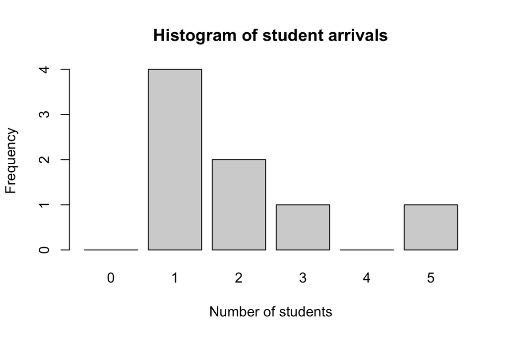

## Count response

\[ Y \in [0,1,\ldots \infty ) \]

We assume

\[Y \sim Poisson(\lambda)\]

Further, theory says:

\[\mu = E(Y) = \lambda>0\] \[\sigma^2 = Var(Y) = \lambda >0\]

## Poisson probability model

The probability mass function mapping the probability of exactly \(k\) events is given by:

\[ P(Y = k) = \frac{\lambda^k \exp(-\lambda)}{k!} \]

## Estimating the Poisson parameter

For the student arrivals data, we can estimate the parameter \(\lambda\) using the maximum likelihood estimate (MLE), which is the sample mean.

```r
# MLE of Poisson parameter lambda is the sample mean
lambda_hat <- mean(students)
lambda_hat
```

```
## [1] 2
```

**So for students** \(\lambda = 2\):

- No-one late (\(k=0\)): \(P(Y=0) = \frac{2^0 \exp(-2)}{0!} = e^{-2} \approx 0.135\)

- Two late (\(k=2\)): \(P(Y=2) = \frac{2^2 \exp(-2)}{2!} = 2e^{-2} \approx 0.271\)

## Shapes of the Poisson distribution

The shape of the Poisson PMF changes directly with \(\lambda\). Here we also overlay \(\lambda=2\) representing our student arrivals data.

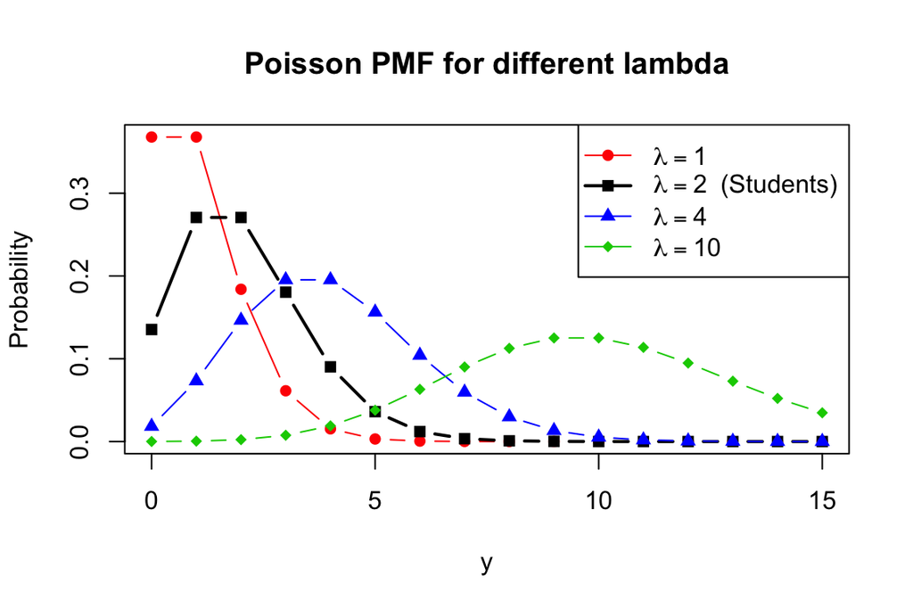

## The log-link function

The canonical link function for Poisson distributed response is the `log`-link.

Hence we assume that the linear predictor

\(\eta_i = \beta_0 + \beta_1 x_{1i} + \cdots + \beta_p x_{pi}\) is related to the mean through the link function:

\[g(\lambda_i) = \log(\lambda_i)\]

by:

\[\log(\lambda_i) = \beta_0 + \beta_1 x_{1i} + \cdots + \beta_p x_{pi}\]

Since we want:

\[{\lambda}_i = \exp({\beta}_0 + {\beta}_1 x_{1i} + \cdots + {\beta}_p x_{pi}) > 0\]

## The inverse link-function

The inverse link function \(\exp()\) provides the estimates of the mean from estimated regression coefficients:

\[\widehat{\lambda}_i = \exp(\widehat{\beta}_0 + \widehat{\beta}_1 x_{1i} + \cdots + \widehat{\beta}_p x_{pi})\]

## Example - Plant Species

Number of plant species in plots of different biomass and pH.

```r
library(BIAS.data)
data(species)
head(species, 4)
```

```
##     pH   Biomass Species
## 1 high 0.4692972      30
## 2 high 1.7308704      39
## 3 high 2.0897785      44
## 4 high 3.9257871      35
```

## Example - Plant Species (Cont.)

Number of plant species in plots of different biomass and pH.

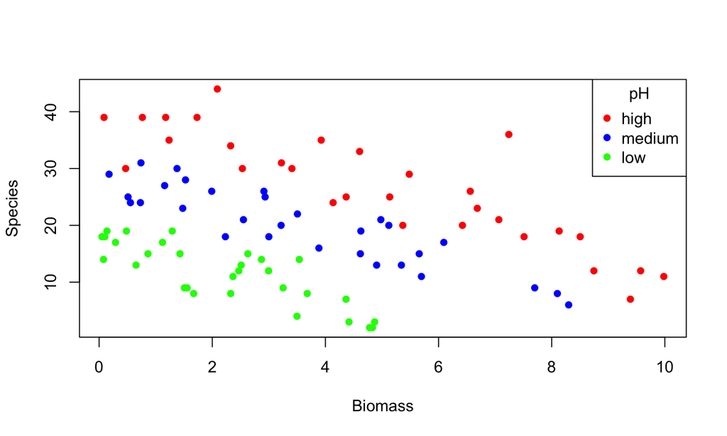

## Species count as function of biomass

A Poisson regression with `Biomass` as predictor:

```r
mod1.glm <- glm(Species ~ Biomass, family=poisson(log), data=species)
summary(mod1.glm)
```

## Output

A Poisson regression with `Biomass` as predictor:

```
##
## Call:
## glm(formula = Species ~ Biomass, family = poisson(log), data = species)
##
## Coefficients:
##              Estimate Std. Error z value Pr(>|z|)
## (Intercept)  3.184094   0.039159   81.31  < 2e-16 ***
## Biomass     -0.064441   0.009838   -6.55 5.74e-11 ***
## ---
## Signif. codes:  0 '***' 0.001 '**' 0.01 '*' 0.05 '.' 0.1 ' ' 1
##
## (Dispersion parameter for poisson family taken to be 1)
##
##     Null deviance: 452.35  on 89  degrees of freedom
## Residual deviance: 407.67  on 88  degrees of freedom
## AIC: 830.86
##
## Number of Fisher Scoring iterations: 4
```

## Delta unit interpretation

Using a log-link makes the interpretation of the slope **multiplicative**. This is easy to derive:

\[ \color{blue}{\log(\mu_{\text{new}})} - \color{blue}{\log(\mu_{\text{old}})} = (\beta_0 + \beta_1(x+\Delta)) - (\beta_0 + \beta_1 x) = \color{red}{\Delta\beta_1} \] \[ \implies \log\left(\frac{\mu_{\text{new}}}{\mu_{\text{old}}}\right) = \color{red}{\Delta\beta_1} \implies \mu_{\text{new}} = \mu_{\text{old}} \color{red}{\exp(\Delta\beta_1)} \]

Taking a \(\Delta\)-unit delta (increase) in predictor \(x_j\) **multiplies** the expected **mean** response **by** \(\exp(\Delta\beta_j)\).

For example, \(\widehat{\beta}_{\text{Biomass}} = -0.0644\). A **1**-unit increase in `Biomass` multiplies the expected species count by \(\exp(-0.0644) \approx 0.938\), which corresponds to a decrease of \(6.2\%\).

## Deviance test for the effect of biomass

```r
anova(mod1.glm,test='LR')
```

```
## Analysis of Deviance Table
##
## Model: poisson, link: log
##
## Response: Species
##
## Terms added sequentially (first to last)
##
##
##         Df Deviance Resid. Df Resid. Dev  Pr(>Chi)
## NULL                       89     452.35
## Biomass  1   44.673        88     407.67 2.328e-11 ***
## ---
## Signif. codes:  0 '***' 0.001 '**' 0.01 '*' 0.05 '.' 0.1 ' ' 1
```

Conclusion: Biomass is highly significant with a negative effect.

## Prediction

What is the predicted species count for a plot with biomass equal to 4?

```r
new <- data.frame(Biomass=4)
    link <- predict(mod1.glm, new, type = "link", se.fit = TRUE)
    response <- predict(mod1.glm, new, type = "response", se.fit = TRUE)
    LS <- cbind(link$fit, link$se.fit, response$fit, response$se.fit)
    colnames(LS) <- c("link", "se.link", "response", "se.response")
    LS
```

## Output

```
##       link    se.link response se.response
## 1 2.926332 0.02530713 18.65906   0.4722072
```

This was found by letting \(x^{*} = 4\) and

\[\widehat{\eta}^{*} = 3.184 - 0.0644\cdot x^{*} = 2.926\]

\[\widehat{y}^{*} = \widehat{\lambda}^{*} = \exp(\widehat{\eta}^{*}) = \exp(2.926) = 18.66\]

## Expanding the model

From the plot we saw that `pH` may have large influence.

```r
mod2.glm <- glm(Species ~ Biomass + pH, family=poisson, data=species)
summary(mod2.glm)
```

## Output (Expanded model)

From the plot we saw that `pH` may have large influence.

```
##
## Call:
## glm(formula = Species ~ Biomass + pH, family = poisson, data = species)
##
## Coefficients:
##             Estimate Std. Error z value Pr(>|z|)
## (Intercept)  3.84894    0.05281  72.885  < 2e-16 ***
## Biomass     -0.12756    0.01014 -12.579  < 2e-16 ***
## pHlow       -1.13639    0.06720 -16.910  < 2e-16 ***
## pHmid       -0.44516    0.05486  -8.114 4.88e-16 ***
## ---
## Signif. codes:  0 '***' 0.001 '**' 0.01 '*' 0.05 '.' 0.1 ' ' 1
##
## (Dispersion parameter for poisson family taken to be 1)
##
##     Null deviance: 452.346  on 89  degrees of freedom
## Residual deviance:  99.242  on 86  degrees of freedom
## AIC: 526.43
##
## Number of Fisher Scoring iterations: 4
```

## Deviance tests

```r
anova(mod2.glm,test='LR')
```

```
## Analysis of Deviance Table
##
## Model: poisson, link: log
##
## Response: Species
##
## Terms added sequentially (first to last)
##
##
##         Df Deviance Resid. Df Resid. Dev  Pr(>Chi)
## NULL                       89     452.35
## Biomass  1   44.673        88     407.67 2.328e-11 ***
## pH       2  308.431        86      99.24 < 2.2e-16 ***
## ---
## Signif. codes:  0 '***' 0.001 '**' 0.01 '*' 0.05 '.' 0.1 ' ' 1
```

## Over/under-dispersion

\(Var(y)\) depends on the mean \(\mu\) in specific ways for the binomial and the Poisson distribution (and others).

Sometimes data vary more (over-dispersion) or less (under-dispersion) than expected.

Over-dispersion is very common in biological data

Usually this is due to some (unknown) factor influencing the data.

## The quasi-likelihood

The quasi-likelihood method relaxes the variance assumption by including a `scale`-parameter.

Over-dispersion corresponds to `scale > 1`

Under-dispersion corresponds to `scale < 1`

We can estimate the scale-parameter using the `family = quasi-` distributions

## If pH was “unknown”…

Assume `pH` was not measured (back to the first model…)

Let’s fit a `quasi-poisson` model and look at the estimates. No change!

```r
mod1q.glm <- glm(Species ~ Biomass, family=quasipoisson, data=species)
sumfit <- summary(mod1q.glm)
sumfit$coefficients
```

## Quasi-Poisson Output

[output not shown]

Compare with the model assuming poisson distribution:

```
##                Estimate  Std. Error   z value     Pr(>|z|)
## (Intercept)  3.18409377 0.039159103 81.311714 0.000000e+00
## Biomass     -0.06444054 0.009837528 -6.550481 5.735197e-11
```

But note the increased standard errors!

## Estimated over/under-dispersion

The estimated dispersion parameter is:

```r
summary(mod1q.glm)$dispersion
```

```
## [1] 4.375969
```

The standard errors of the estimated regression coefficients have increased by a factor of \(\sqrt{4.376}= 2.091\)

There exist formal tests for over/under-dispersion:

- Parametric Pearson residuals test
- Nonparametric Pearson residuals test
- Simulation-based residual variance test
- Etc.

## Gamma regression

For continuous variables that are strictly positive and often right-skewed, we can use the **Gamma distribution**.

Its probability density function is: \[f(y) = \frac{1}{\Gamma(\nu)} \left( \frac{\nu}{\mu} \right)^\nu y^{\nu - 1} \exp\left( - \frac{\nu y}{\mu} \right)\] for \(y > 0\), where \(\mu > 0\) is the mean and \(\nu > 0\) is the shape parameter.

The variance of a Gamma distributed variable is proportional to the square of its mean, \(Var(y) = \mu^2 / \nu\), making it ideal when larger responses have higher variance.

To ensure that the predicted mean \(\mu\) is always positive, we typically use the **log-link**: \[g(\mu) = \log(\mu) = \beta_0 + \beta_1 x_{1} + \cdots + \beta_p x_{p}\]

## Shapes of the Gamma distribution

The Gamma PDF is highly flexible based on the shape (\(\nu\)) and mean (\(\mu\)).

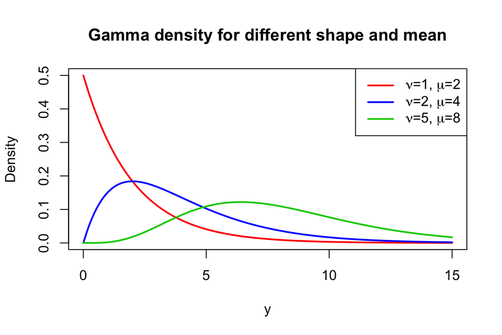

## Gamma regression example

Consider the `Auto` dataset from the `ISLR` package. We want to predict the continuous and strictly positive `mpg` (miles per gallon) based on vehicle `weight` and `horsepower`.

```r
library(ISLR)
data(Auto)
head(Auto[, c("mpg", "weight", "horsepower")], 3)
```

```
##   mpg weight horsepower
## 1  18   3504        130
## 2  15   3693        165
## 3  18   3436        150
```

## Why not Gaussian?

If we look at the distribution of `mpg`, it is strictly positive and right-skewed. A standard Gaussian regression assumes symmetric errors with constant variance, which is not suitable here.

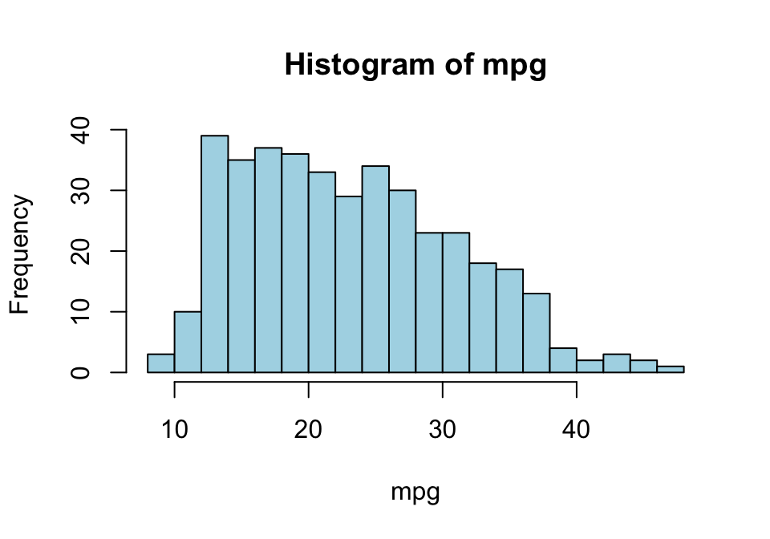

## Gamma regression fit

```r
mod.gamma <- glm(mpg ~ weight + horsepower,
                 family=Gamma(link="log"), data=Auto)
```

[output not shown]

## Gamma Interpretation

Both predictors have a significant negative effect on the expected `mpg`. The variance assumption of the Gamma model naturally handles the heteroscedasticity common in this type of data.

Because we use the **log-link**, a 1-unit increase in the predictor \(x_j\) multiplies the expected mean response by \(\color{red}{\exp(\beta_j)}\). For instance, since \(\widehat{\beta}_{\text{weight}} = -0.00025\), an increase of 1000 units in `weight` multiplies the expected `mpg` by \(\color{red}{\exp(-0.25) \approx 0.78}\).

## The Multinomial Distribution

Consider \(N\) **independent trials**, each resulting in exactly one of \(t\) **categories** (bins) with fixed probabilities \(\mathbf{p} = (p_1, p_2, \ldots, p_t)\), where \(\sum_{j=1}^t p_j = 1\).

Let \(Y_j\) = number of trials falling in category \(j\). Then the vector \((Y_1, Y_2, \ldots, Y_t)\) follows a **Multinomial distribution**:

\[\mathbf{Y} \sim \text{Multinomial}(N,\, \mathbf{p})\]

with joint probability mass function:

\[P(Y_1 = k_1, \ldots, Y_t = k_t) = \frac{n!}{k_1!\, k_2!\, \cdots\, k_t!}\; p_1^{k_1}\, p_2^{k_2}\, \cdots\, p_t^{k_t}\]

where \(k_1 + k_2 + \cdots + k_t = N\) and for each \(j\): \(E(Y_j) = N p_j\), \(\quad Var(Y_j) = N p_j (1-p_j)\).

**Note:** When \(t=2\) this reduces to the familiar **Binomial** distribution.

## Multinomial: Bins & Trials Illustration

\(N = 20\) trials distributed across \(t = 4\) categories:

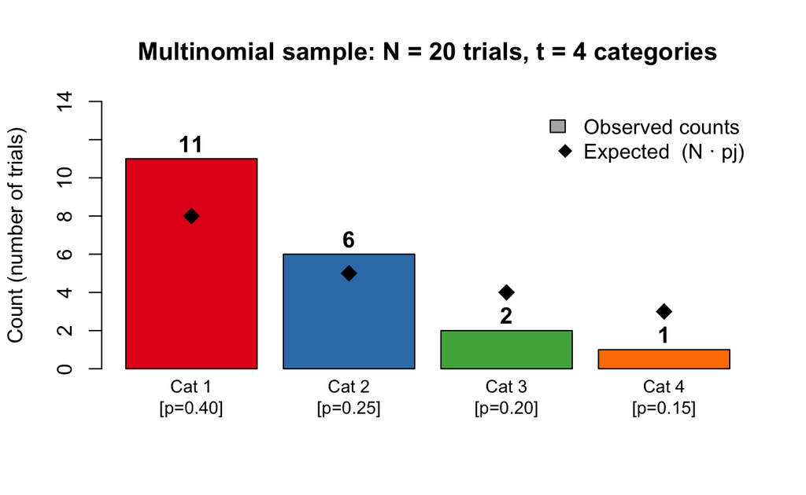

Each bar = one **bin** (category); bar height = how many trials landed there.

## Categorical Distribution when \(N=1\)

When we perform only **one trial** (\(N = 1\)), each \(Y_j \in \{0,1\}\) and exactly one \(Y_j = 1\). This is the **Categorical distribution**:

\[Y \sim \text{Categorical}(\mathbf{p}), \quad P(Y_j = 1) = p_j, \quad j = 1,\ldots,t\]

Think of it as a single **roll of a weighted** \(t\)-sided die.

**Connection to regression:** In multinomial regression each observation \(i\) is modelled as one Categorical trial with class-probabilities \(p_{ij}\) driven by covariates \(\mathbf{x}_i\).

**Note:** When \(t=2\) this reduces to the familiar **Bernoulli** distribution.

## Example - Iris Species

We want to predict `Species` (setosa, versicolor, virginica) of iris flowers based on their `Sepal.Length` and `Sepal.Width`

Let \(i\) denote a flower, and we have categorical outcome \(j=1\) (setosa), \(j=2\) (versicolor), \(j=3\) (virginica).

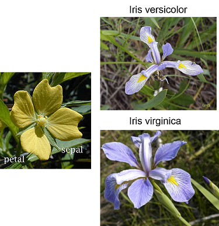

```
##   Sepal.Length Species
## 1          5.1  setosa
```

## Multinomial model assumptions

Given a flower-specific linear predictor \(\eta_{ij}\) for flower \(i\) and species \(j\), the probability of outcome \(j\) is modelled as:

\[p_{ij} = \frac{\exp(\eta_{ij})}{\sum_k \exp(\eta_{ik})} \text{; known as softmax function}\]

where \(\eta_{ij} = \beta_{0j} + \beta_{1j} \cdot \text{Sepal.Length}_i + \beta_{2j} \cdot \text{Sepal.Width}_i\).

We use baseline response parameterization (default in R) where the first category (setosa) is the reference, so we set \(\eta_{i1} = 0\). This gives a simplification for \(j=1\):

\[p_{i1} = 1 - p_{i2} - p_{i3}\]

## R code (Baseline parameterization)

Let’s use the `nnet` package to fit the model.

```r
MLM.iris <- nnet::multinom(Species ~ Sepal.Length + Sepal.Width,
                            data=iris, trace=FALSE)
summary(MLM.iris)
```

```
## Call:
## nnet::multinom(formula = Species ~ Sepal.Length + Sepal.Width,
##     data = iris, trace = FALSE)
##
## Coefficients:
##            (Intercept) Sepal.Length Sepal.Width
## versicolor   -92.09924     40.40326   -40.58755
## virginica   -105.10096     42.30094   -40.18799
##
## Std. Errors:
##            (Intercept) Sepal.Length Sepal.Width
## versicolor    26.27831     9.142717    27.77772
## virginica     26.37025     9.131119    27.78875
##
## Residual Deviance: 110.425
## AIC: 122.425
```

Here `setosa` is the baseline response. The model estimates two sets of coefficients: one for `versicolor` and one for `virginica`.

## Calculating Probabilities

For a given flower with `Sepal.Length = 5` cm and `Sepal.Width = 3` cm, the linear predictors are computed from the estimated coefficients:

```r
new_data <- data.frame(Sepal.Length=5, Sepal.Width=3)
round(predict(MLM.iris, newdata=new_data, type="probs"), 4)
```

```
##     setosa versicolor  virginica
##          1          0          0
```

## Classification Accuracy (Linear Model)

We can evaluate the model’s classification accuracy over the entire dataset:

```r
predicted_classes <- predict(MLM.iris, newdata=iris, type="class")
accuracy <- mean(predicted_classes == iris$Species)
round(accuracy, 3)
```

```
## [1] 0.833
```

```r
table(Predicted = predicted_classes, Actual = iris$Species)
```

```
##             Actual
## Predicted    setosa versicolor virginica
##   setosa         50          0         0
##   versicolor      0         38        13
##   virginica       0         12        37
```

## Linear Decision Boundary in 2D

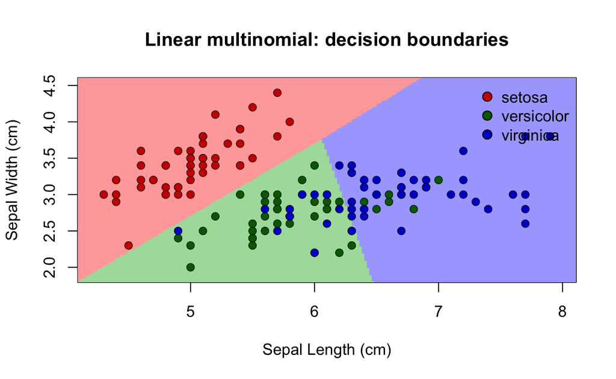

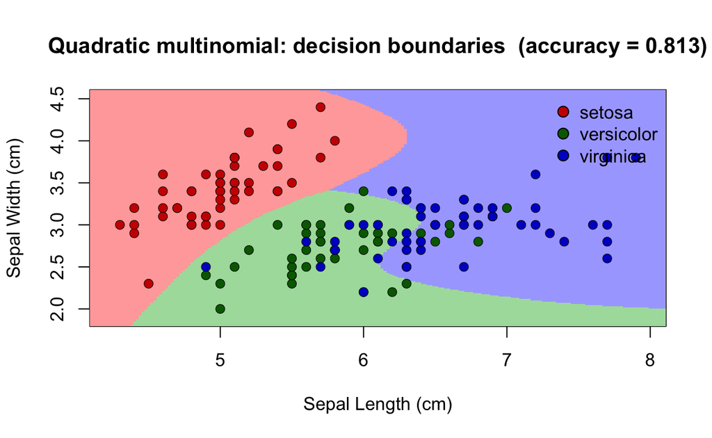